## 1. Objective: a forecast before the first ball

Predict a team’s **actual first-innings total**, including extras.

Prediction time: **after the toss and initial XI announcement, before play**.

Analysts can compare the eventual score with a realistic pre-match expectation.

## 1. Objective: what the study asks

- Can we beat the historical mean and earlier venue average?
- Do player strength and season context improve forecasts?
- Can PCA, FA and venue groups simplify the model?
- How much do influential innings and unequal variance matter?

Success means lower error on the reserved final season; the result may be negative.

## 2. Data: earlier seasons teach, later seasons assess

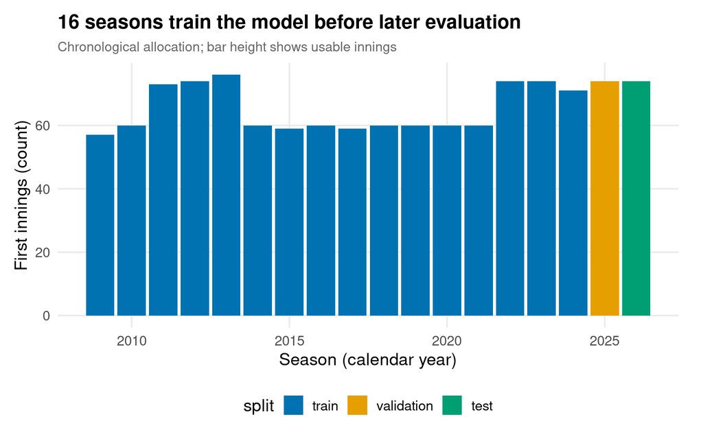

One row per first innings. Source: Cricsheet CSV, with JSON for initial-XI reconstruction.

## 2. Data: scores have substantial variation

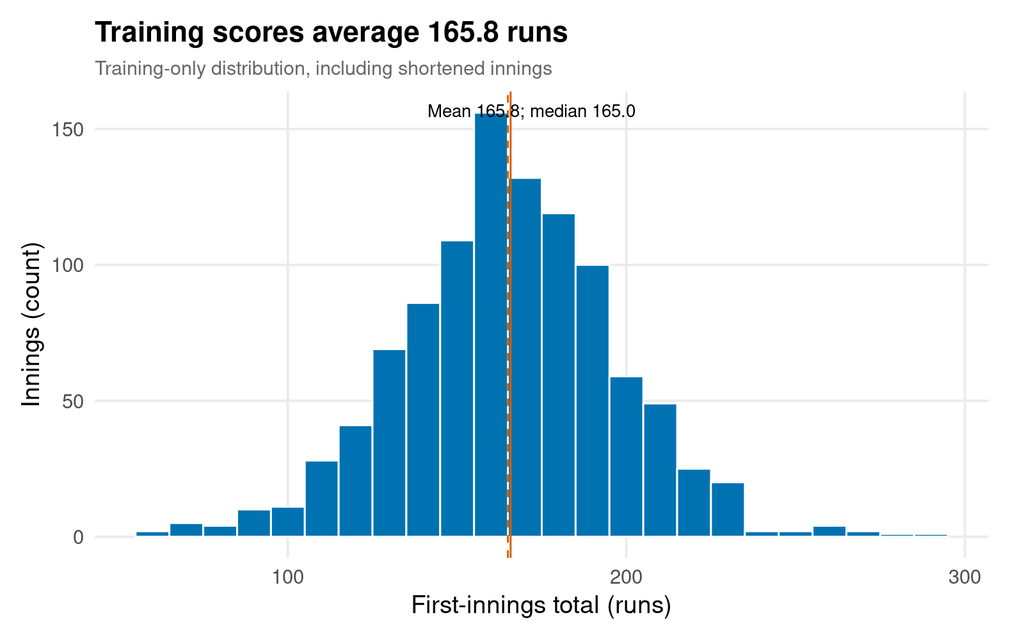

Shortened innings remain part of the actual-total question.

## 3. Methods: build history, then fit regression

- R imports, cleans and aggregates deliveries.
- Every historical feature uses **strictly earlier dates**.
- Simple regression starts with venue; multiple regression adds team strength and context.
- The class examples compare full regression and backward AIC selection.

Every candidate pool and fitted regression must pass the course’s predictor limit.

## 3. Methods: simplify related measurements

**PCA:** summarises total variation in strength measurements.

**Factor Analysis:** models shared variation plus uniqueness.

**Clustering:** groups similar historical venue profiles.

Scaling, loadings, factor weights and cluster centres are learned from training seasons.

## 3. Methods: diagnose and evaluate honestly

Influence checks lead to sensitivity analysis, not automatic deletion.

Goldfeld–Quandt testing, log-response regression and group-variance WLS inspect unequal variance.

RMSE measures large-error sensitivity; MAE measures typical absolute error.

## 4. Results: venue is an imperfect scoring anchor

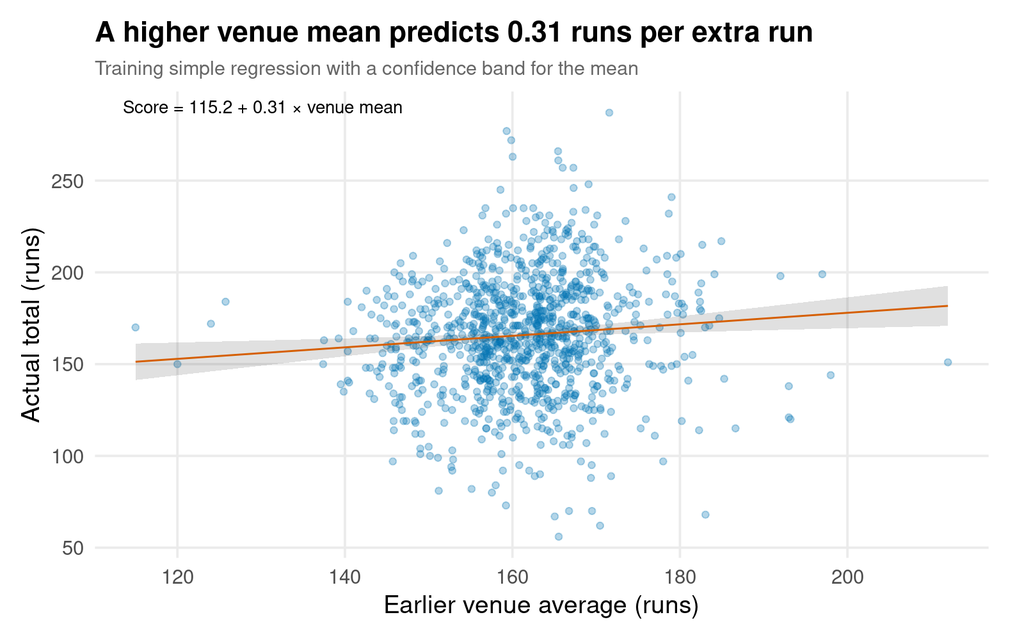

The confidence band concerns the average relationship; individual innings vary much more.

## 4. Results: compression must preserve useful signal

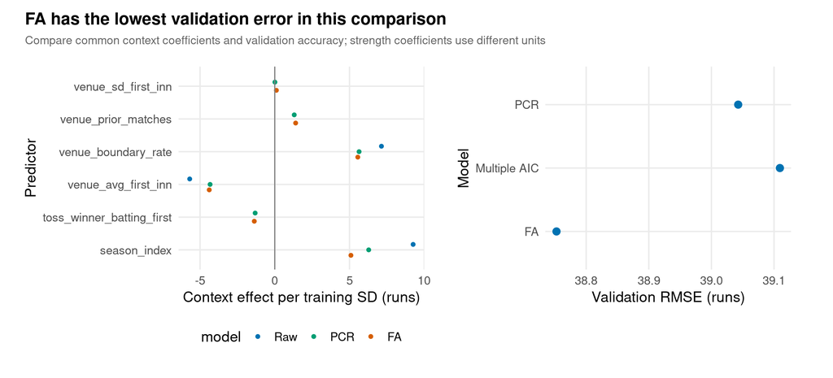

The combined analysis retains 3 PCs and 3 factors.

## 4. Results: venue groups describe historical context

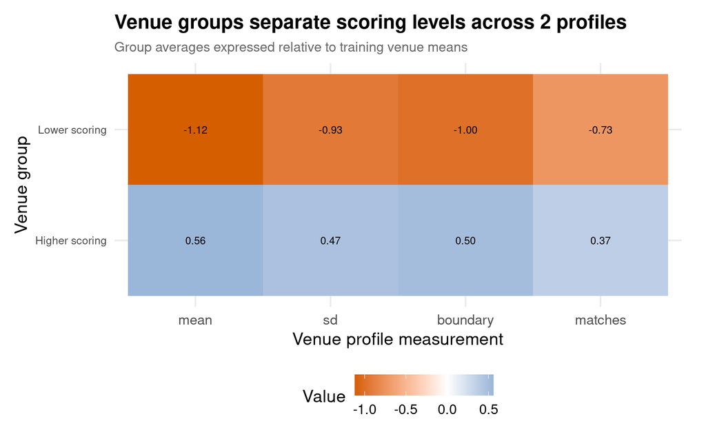

Groups remain frozen when later innings are predicted.

## 4. Results: unusual innings deserve inspection

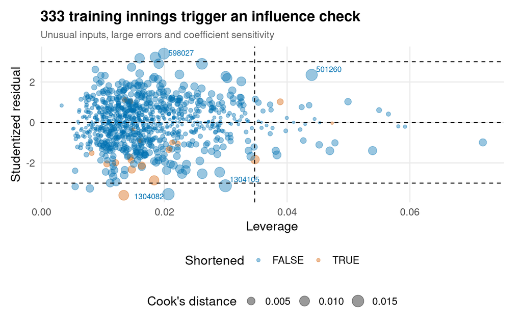

Valid extremes stay relevant to the forecasting problem.

## 4. Results: the frozen comparison decides practical value

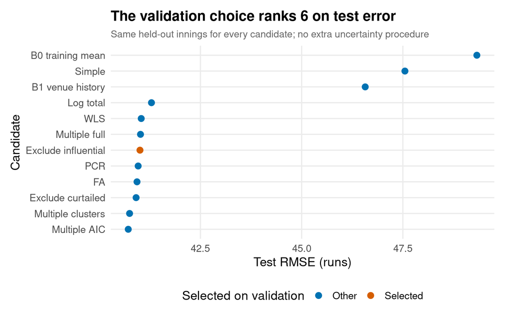

Selected using validation: **Exclude influential**. Test interval coverage: **58.1%**.

## 5. Conclusion: an expectation with measured uncertainty

**Exclude influential**: test RMSE **41 runs**, MAE **32.1 runs**.

The selected model beats both baselines on test.

Predictive R-squared is **0.006**: most individual-innings variation remains unexplained.

Shortened matches, sparse history and season shifts limit precision.

The main learning: apply every method with a purpose, diagnose it, and explain what its evidence supports.